# Transit Oriented Development for Newark & Jersey City, NJ

Chris Michael

September 17, 2022

# A. Policy Brief

### To, the City Council Representatives of Newark & Jersey City

Transportation systems have long been considered essential to growth and development in urban regions. Roads, freeways, trains, buses, and trams form the backbone of cities across the world by providing a network to connect people with jobs and housing, and enabling the movement of goods and capital. They create a way for people to earn an income, access amenities, and consume goods and services. By the very nature and purpose of transportation systems, it can be assumed that they would have a positive impact on economic mobility. **Yet, to what extent do households value transit-rich neighborhoods compared to others?**

**There has been a larger increase in population in TOD areas compared to non-TOD areas over the years**

There has been an *8.6% increase* in the population living in TOD areas, and a *1.7% increase* in the population living in non-TOD areas in the two counties over the decade. This growth could be attributed to a larger portion of the population choosing to live in close proximity to transit stations for commute to work and for easier access to urban amenities. The percent of white population has remained relatively unchanged in TOD regions, while the percent of black population *decreased by 17.2%*. Both racial groups saw a decrease in population in non-TOD regions. It can be difficult to determine what causes these changes- could be ageing in place, change in demographics, or simple migration in search of better job opportunities.

**There has been an increase in the proportion of educated popuation in TOD areas over the years**

**Concluding thoughts**

From this preliminary analysis, it can be difficult to say that households value transit-rich neighborhoods and are willing to pay for proximity to these regions. There are multiple factors that affect demographic and household shifts over time. Presence of public transit infrastructure along with pedestrian and bike accessibility have to be considered while analyzing the difference between TOD and non-TOD neighborhoods. In addition to that, mode of commute to work, type of employment sector, presence of school districts, access to food and healthcare options are all important factors that affect household formation in a region. For a future study, layering various indicators over public transit infrastructure may help us better understand the benefits of Transit Oriented Development.

# B. Set-Up

### I. Installing Packages

```r
library(tidyverse)
library(tidycensus)
library(dplyr)
library(sf)
library(kableExtra)
library(RColorBrewer)
library(hrbrthemes)
library(viridis)
library(ggthemes)
library(ggplot2)
library(plotly)
library(scales)
library(extrafont)
library(basetheme)
library(RColorBrewer)
library(lemon)
library(data.table)
library(GGally)
require(gridExtra)
library(ggalt)
library(rgeos)
library(sp)
library(smoothr)
library(rgdal)
library(rgeos)
library(maptools)
library(ggmap)
library(scales)
library(ggeasy)
library("wesanderson")

options(scipen = 999)
options(tigris_class = "sf")

source("https://raw.githubusercontent.com/urbanSpatial/Public-Policy-Analytics-Landing/master/functions.r")
```

```r
tracts09_1 <-
  get_acs(geography = "tract",
          variables = c("B25026_001E","B02001_002E",
                        "B15001_050E","B15001_009E",
                        "B19013_001E", "B25058_001E",
                        "B06012_002E", "B02001_003E"),
          year=2009, state=34, county=017,
          geometry=TRUE, output="wide") %>%
  rename(TotalPop = B25026_001E,
         Whites = B02001_002E,
         TBlacks = B02001_003E,
         FemaleBachelors = B15001_050E,
         MaleBachelors = B15001_009E,
         MedHHInc = B19013_001E,
         MedRent = B25058_001E,
         TotalPoverty = B06012_002E) %>%
  dplyr::select(-NAME, -starts_with("B")) %>%
  mutate(pctWhite = ifelse(TotalPop > 0, Whites / TotalPop,0),
         pctBlack = ifelse (TotalPop > 0, TBlacks / TotalPop, 0),
         pctBachelors = ifelse(TotalPop > 0, ((FemaleBachelors + MaleBachelors) / TotalPop),0),
         pctPoverty = ifelse(TotalPop > 0, TotalPoverty / TotalPop, 0),
         year = "2009") %>%
  dplyr::select(-Whites, -FemaleBachelors, -MaleBachelors, -TotalPoverty)

tracts09_2 <-
  get_acs(geography = "tract",
          variables = c("B25026_001E","B02001_002E",
                        "B15001_050E","B15001_009E",
                        "B19013_001E", "B25058_001E",
                        "B06012_002E", "B02001_003E"),
          year=2009, state=34, county=013,
          geometry=TRUE, output="wide") %>%
  rename(TotalPop = B25026_001E,
         Whites = B02001_002E,
         TBlacks = B02001_003E,
         FemaleBachelors = B15001_050E,
         MaleBachelors = B15001_009E,
         MedHHInc = B19013_001E,
         MedRent = B25058_001E,
         TotalPoverty = B06012_002E) %>%
  dplyr::select(-NAME, -starts_with("B")) %>%
  mutate(pctWhite = ifelse(TotalPop > 0, Whites / TotalPop,0),
         pctBlack = ifelse (TotalPop > 0, TBlacks / TotalPop, 0),
         pctBachelors = ifelse(TotalPop > 0, ((FemaleBachelors + MaleBachelors) / TotalPop),0),
         pctPoverty = ifelse(TotalPop > 0, TotalPoverty / TotalPop, 0),
         year = "2009") %>%
  dplyr::select(-Whites, -FemaleBachelors, -MaleBachelors, -TotalPoverty)

tracts09 <- rbind(tracts09_1,tracts09_2)

tracts19_1 <-
  get_acs(geography = "tract",
          variables = c("B25026_001E","B02001_002E",
                        "B15001_050E","B15001_009E",
                        "B19013_001E", "B25058_001E",
                        "B06012_002E", "B02001_003E"),
          year=2019, state=34, county=017,
          geometry=TRUE, output="wide") %>%
  rename(TotalPop = B25026_001E,
         Whites = B02001_002E,
         TBlacks = B02001_003E,
         FemaleBachelors = B15001_050E,
         MaleBachelors = B15001_009E,
         MedHHInc = B19013_001E,
         MedRent = B25058_001E,
         TotalPoverty = B06012_002E) %>%
  dplyr::select(-NAME, -starts_with("B")) %>%
  mutate(pctWhite = ifelse(TotalPop > 0, Whites / TotalPop,0),
         pctBlack = ifelse (TotalPop > 0, TBlacks / TotalPop, 0),
         pctBachelors = ifelse(TotalPop > 0, ((FemaleBachelors + MaleBachelors) / TotalPop),0),
         pctPoverty = ifelse(TotalPop > 0, TotalPoverty / TotalPop, 0),
         year = "2019") %>%
  dplyr::select(-Whites, -FemaleBachelors, -MaleBachelors, -TotalPoverty)

tracts19_2 <-
  get_acs(geography = "tract",
          variables = c("B25026_001E","B02001_002E",
                        "B15001_050E","B15001_009E",
                        "B19013_001E", "B25058_001E",
                        "B06012_002E", "B02001_003E"),
          year=2019, state=34, county=013,
          geometry=TRUE, output="wide") %>%
  rename(TotalPop = B25026_001E,
         Whites = B02001_002E,
         TBlacks = B02001_003E,
         FemaleBachelors = B15001_050E,
         MaleBachelors = B15001_009E,
         MedHHInc = B19013_001E,
         MedRent = B25058_001E,
         TotalPoverty = B06012_002E) %>%
  dplyr::select(-NAME, -starts_with("B")) %>%
  mutate(pctWhite = ifelse(TotalPop > 0, Whites / TotalPop,0),
         pctBlack = ifelse (TotalPop > 0, TBlacks / TotalPop, 0),
         pctBachelors = ifelse(TotalPop > 0, ((FemaleBachelors + MaleBachelors) / TotalPop),0),
         pctPoverty = ifelse(TotalPop > 0, TotalPoverty / TotalPop, 0),
         year = "2019") %>%
  dplyr::select(-Whites, -FemaleBachelors, -MaleBachelors, -TotalPoverty)

tracts19 <- rbind(tracts19_1,tracts19_2)

allTracts <- rbind(tracts09,tracts19)
```

I started creating the markdown by installing the required packages and loading them into the library. Some of the mainly used packages are `__tidyverse__`, `__tidycensus__`, and `__dplyr__`. The final deliverable for this homework is an RMarkdown file with the required plots and tables, knitted to a HTML document. I pulled data from the 2009 and 2019 5-year American Community Survey (ACS) from the U.S Census Bureau. The selected geographies are Hudson and Essex counties in New Jersey.

# C. The Hudson County Light Rail System

Most of the information in this section was sourced from the New Jersey Geographic Information Network (NJGIN) Open Data portal. Newark and Jersey City are the two most populous cities in New Jersey, so I decided to filter my results for Hudson and Essex counties, where they’re located.

```r
NJ_Stops <- st_read("C:/Users/Chris Michael/Desktop/UPenn/Fall 2022/508/MUSA_508_Lab-main/MUSA_508_Lab-main/Week_2/Light_Rail_Stations_of_NJ_Transit.geojson") %>%
  st_transform(st_crs(tracts09)) %>%
  dplyr::filter (COUNTY %in% c ("Hudson","Essex"))
```

### I. Visualizing the Hudson-Bergen Light Rail Stations

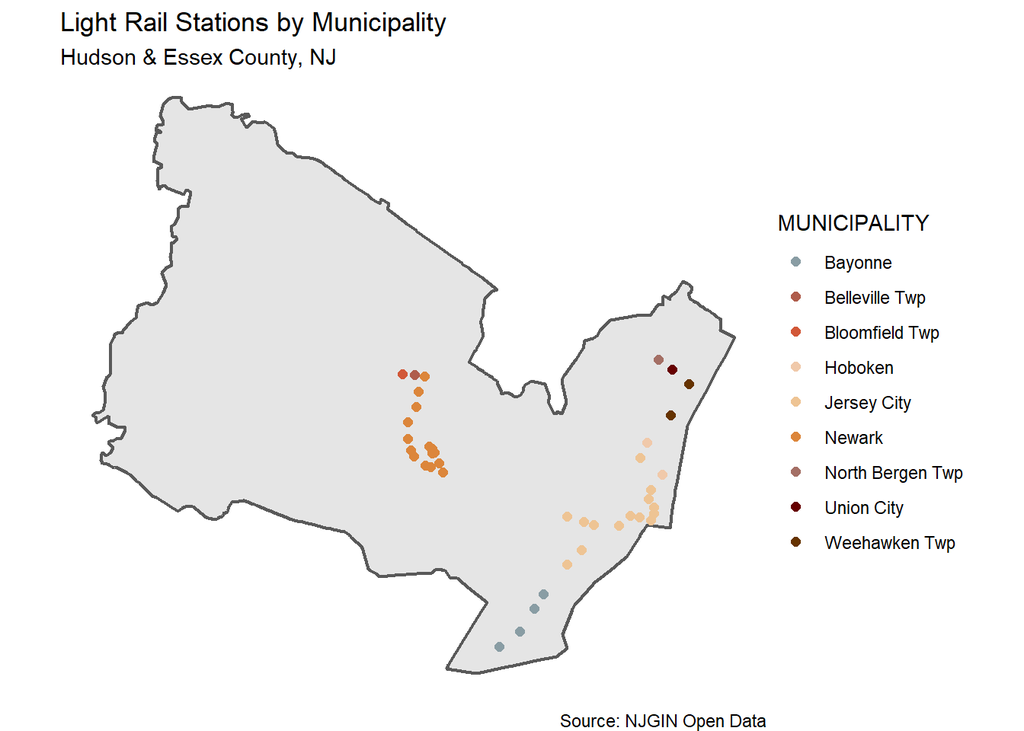

```r
col <- wes_palette("Royal1")
col5 <- colorRampPalette(col)(5)
col6 <- colorRampPalette(col)(6)
col29 <- colorRampPalette(col)(29)

ggplot() +
  geom_sf(data=st_union(tracts09),size=0.75) +
  geom_sf(data=NJ_Stops, aes(color=MUNICIPALITY), size=2) +
  scale_color_manual(values = c("#899da4","#af5d4c","#d25838","#f0c9aa",
                                "#eec494","#dc863b","#a46f65","#660000","#663300"))+
  labs(title="Light Rail Stations by Municipality",
       subtitle="Hudson & Essex County, NJ",
       caption="Source: NJGIN Open Data") +
  theme_void()
```

### II. Creating Buffers around the Light Rail Stations

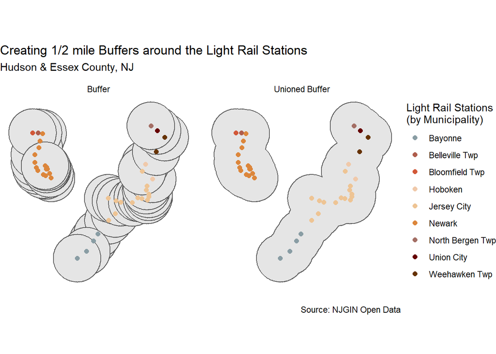

```r
NJ_Buffers <-
  rbind(st_buffer(NJ_Stops, 2640) %>%
      mutate(Legend = "Buffer") %>%
      dplyr::select(Legend),
    st_union(st_buffer(NJ_Stops, 2640)) %>%
      st_sf() %>%
      mutate(Legend = "Unioned Buffer"))

ggplot() +
  geom_sf(data=NJ_Buffers) +
  geom_sf(data=NJ_Stops, aes(color=MUNICIPALITY), size=2, show.legend = "point") +
  scale_color_manual(values = c("#899da4","#af5d4c","#d25838","#f0c9aa",
                                "#eec494","#dc863b","#a46f65","#660000","#663300"),
                    name = "Light Rail Stations\n(by Municipality)")+
  facet_wrap(~Legend) +
  labs(title="Creating 1/2 mile Buffers around the Light Rail Stations",
       subtitle = "Hudson & Essex County, NJ\n",
       caption="\nSource: NJGIN Open Data") +
  theme_void()
```

```r
buffer <- filter(NJ_Buffers, Legend=="Unioned Buffer")
```

### III. Spatial Selection Techniques

The 3 spatial selections techiques used in this section are `__clip__`, `__spatial_selection__` and `__centroid__`. All three techiques are plotted, however the centroid technique will be used extensively throughout this assignment because it does not alter the geometries of the census tracts during selection.

```r
sf::sf_use_s2(FALSE)

clip <- st_intersection(buffer, tracts09) %>%
  dplyr::select(TotalPop) %>%
  mutate(Selection_Type = "by Clip")

selection <- tracts09 %>%
  st_join(buffer, join = st_intersects) %>%
  filter(!is.na(Legend)) %>%
  dplyr::select(TotalPop) %>%
  mutate(Selection_Type = "by Spatial Intersects")

centroids <- st_centroid(tracts09)[buffer,] %>%
  st_drop_geometry() %>%
  left_join(., dplyr::select(tracts09, GEOID), by = "GEOID") %>%
  st_sf() %>%
  dplyr::select(TotalPop) %>%
  mutate(Selection_Type = "by Centroids")

centroids2 <- st_centroid(tracts09)[buffer,] %>%
  st_drop_geometry() %>%
  left_join(., dplyr::select(tracts09, GEOID), by = "GEOID") %>%
  st_sf() %>%
  dplyr::select(MedRent) %>%
  mutate(Selection_Type = "by Centroids")

intersections <- rbind(clip, selection, centroids)
```

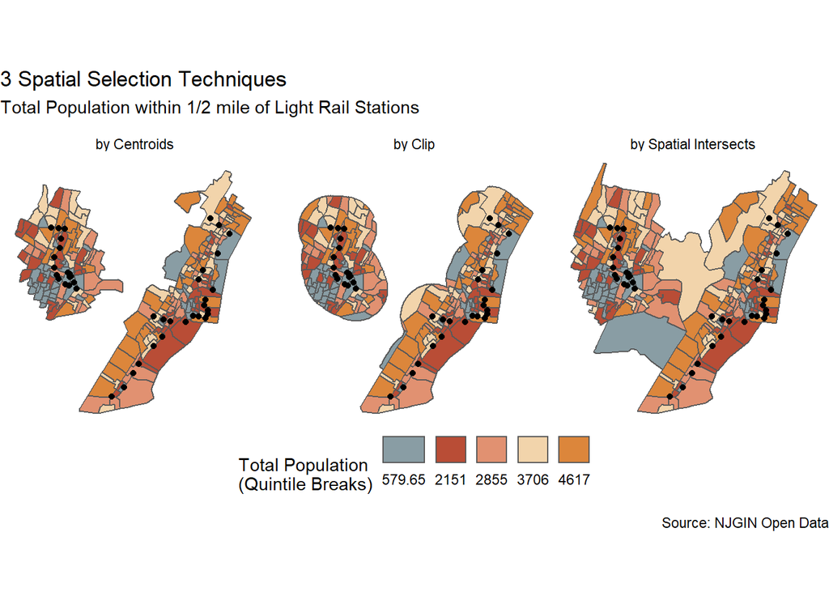

```r
ggplot() +
  geom_sf(data=intersections, aes(fill = q5(TotalPop))) +
  geom_sf(data=NJ_Stops) +
  scale_fill_manual(values = col5,
                    labels = qBr(intersections, "TotalPop"),
                    name = "\nTotal Population\n(Quintile Breaks)") +
  facet_wrap(~Selection_Type) +
  labs(title="3 Spatial Selection Techniques",
       subtitle = "Total Population within 1/2 mile of Light Rail Stations\n",
       caption="\nSource: NJGIN Open Data") +
  theme_void()+
  theme(legend.position="bottom")+
  guides(fill = guide_legend(label.position = "bottom"))
```

# D. Developing TOD Indicators

### I. TOD Time-Space Groups

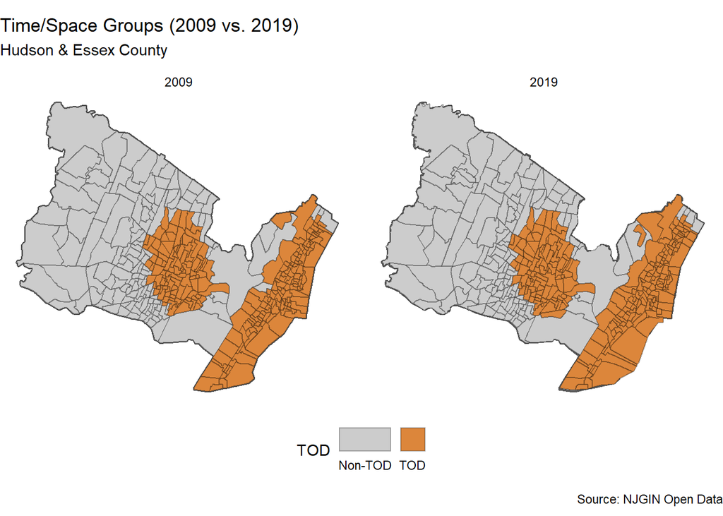

```r
sf::sf_use_s2(FALSE)

allTracts.group <-
  rbind(st_centroid(allTracts)[buffer,] %>%
      st_drop_geometry() %>%
      left_join(allTracts) %>%
      st_sf() %>%
      mutate(TOD = "TOD"),
    st_centroid(allTracts)[buffer, op = st_disjoint] %>%
      st_drop_geometry() %>%
      left_join(allTracts) %>%
      st_sf() %>%
      mutate(TOD = "Non-TOD")) %>%
  mutate(MedRent.inf = ifelse(year == "2009", MedRent * 1.19, MedRent)) %>%
  mutate(MedHHInc.inf=ifelse(year == "2009", MedHHInc * 1.19, MedHHInc))

cola <-   adjustcolor( "black", alpha.f = 0.3)

ggplot(allTracts.group)+
    geom_sf(data=st_union(tracts09), size=0.75) +
    geom_sf(data=buffer,fill=NA, color=NA) +
    geom_sf(aes(fill = TOD), color=cola) +
  scale_fill_manual(values = c("#cccccc","#dc863b")) +
    labs(title="Time/Space Groups (2009 vs. 2019)",
       subtitle = "Hudson & Essex County\n",
       caption="\nSource: NJGIN Open Data") +
    facet_wrap(~year)+
    theme_void()+
  theme(legend.position="bottom")+
  guides(fill = guide_legend(label.position = "bottom"))
```

The noticeable detail about these maps is that there seems to have been a redrawing of tracts in Hudson County, which has resulted in slight variations of TOD and non-TOD areas between 2009 and 2019.

### II. TOD Variables Over Time

#### i. Total Population (2009-2019)

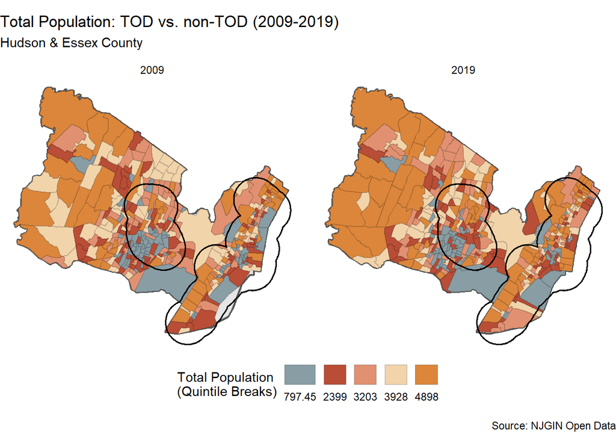

```r
colb <-   adjustcolor( "black", alpha.f = 0.15)

ggplot() +
    geom_sf(data=st_union(allTracts.group), size=0.75) +
    geom_sf(data=(allTracts.group), aes(fill=q5(TotalPop)),color=colb) +
    geom_sf(data =buffer, color ="black", fill= NA, size=0.7)+
  scale_fill_manual(values = col5,
                    labels = qBr(allTracts.group, "TotalPop"),
                    name = "Total Population\n(Quintile Breaks)") +
    labs(title="Total Population: TOD vs. non-TOD (2009-2019)",
       subtitle = "Hudson & Essex County\n",
       caption="\nSource: NJGIN Open Data") +
    facet_wrap(~year)+
    theme_void()+
  theme(legend.position="bottom")+
  guides(fill = guide_legend(label.position = "bottom"))
```

From the map alone, there does not seem to be a significant change in total population in non-TOD zones. There seems to be a slight population increase within the TOZ zones that can only be verified through bar plots and graphs of the data. Overall there hasn’t been a vast change in population over the decade, which we can speculate to be caused by ageing in place, and no significant in or out migration during this time.

#### ii. Median Household Income (2009-2019)

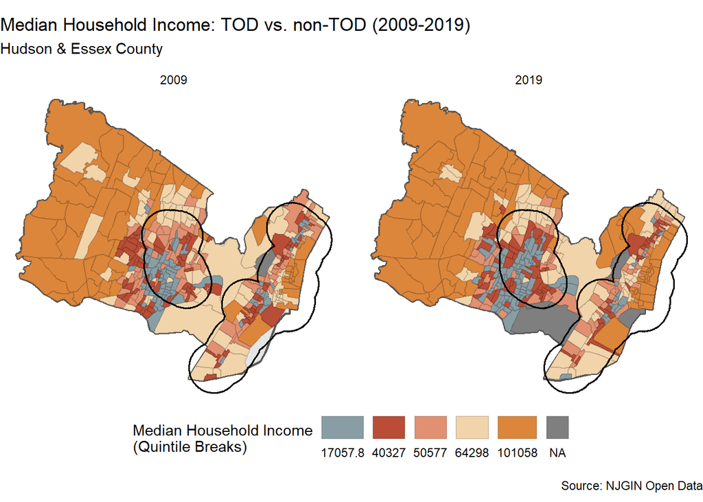

```r
ggplot() +
    geom_sf(data=st_union(allTracts.group), size=0.75) +
    geom_sf(data=(allTracts.group), aes(fill=q5(MedHHInc.inf)),color=colb) +
    geom_sf(data =buffer, color ="black", fill= NA, size=0.7)+
  scale_fill_manual(values = col5,
                    labels = qBr(allTracts.group, "MedHHInc.inf"),
                    name = "Median Household Income\n(Quintile Breaks)") +
    labs(title="Median Household Income: TOD vs. non-TOD (2009-2019)",
       subtitle = "Hudson & Essex County\n",
       caption="\nSource: NJGIN Open Data") +
    facet_wrap(~year)+
    theme_void()+
  theme(legend.position="bottom")+
  guides(fill = guide_legend(label.position = "bottom", nrow = 1))
```

From the maps, it can be observed that median income increases as we move away from the light rail stations, particularly in non-TOD areas. This could imply that people with higher purchasing power are choosing to live further away from public transit infrastructure, and rely on private transportation instead. There also seems to be a higher concentration of lower income residents within the TOD zones, particularly in Essex county. It is difficult to make assumptions based on this map alone, because demographics, employment and the presence of public transit (other than the light rail), can heavily influence where people choose to live and what they can afford.

#### iii. Median Rent (2009-2019)

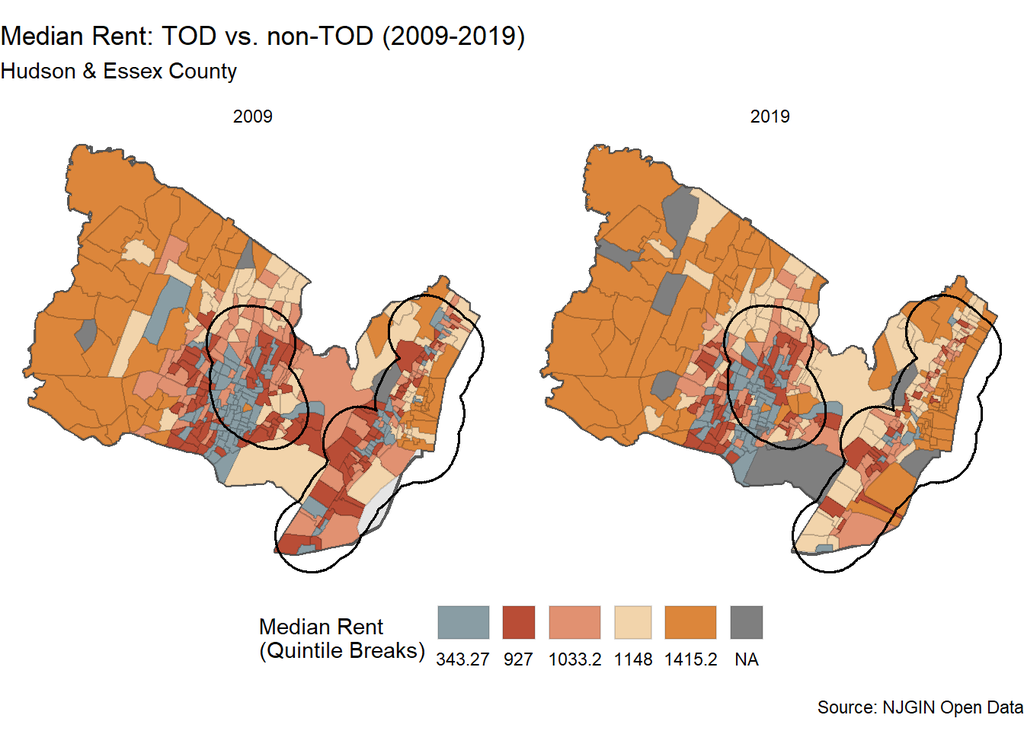

```r
ggplot() +
    geom_sf(data=st_union(allTracts.group), size=0.75) +
    geom_sf(data=(allTracts.group), aes(fill=q5(MedRent.inf)),color=colb) +
    geom_sf(data =buffer, color ="black", fill= NA, size=0.7)+
  scale_fill_manual(values = col5,
                    labels = qBr(allTracts.group, "MedRent.inf"),
                    name = "Median Rent\n(Quintile Breaks)") +
    labs(title="Median Rent: TOD vs. non-TOD (2009-2019)",
       subtitle = "Hudson & Essex County\n",
       caption="\nSource: NJGIN Open Data") +
    facet_wrap(~year)+
    theme_void()+
  theme(legend.position="bottom")+
  guides(fill = guide_legend(label.position = "bottom", nrow = 1))
```

From the maps, rent seems to be increasing in both TOD and non-TOD zones. An increase in rent that is not supplemented by an increase in income can affect affordability. Maybe a closer look into the data would tell us whether more than 30% of a person’s income goes into rent- which would imply decreasing affordability. The proximity of Newark and Jersey City to New York could also be contributing to these hikes in rent over the years, as people leave the NYC region in search of affordable housing options that are close to public transit networks.

#### iv. Percentage of Poverty (2009-2019)

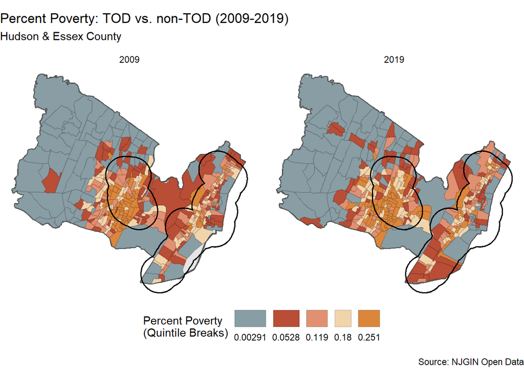

```r
ggplot() +
    geom_sf(data=st_union(allTracts.group), size=0.75) +
    geom_sf(data=(allTracts.group), aes(fill=q5(pctPoverty)),color=colb) +
    geom_sf(data =buffer, color ="black", fill= NA, size=0.7)+
  scale_fill_manual(values = col5,
                    labels = qBr(allTracts.group, "pctPoverty",rnd = F),
                    name = "Percent Poverty\n(Quintile Breaks)") +
    labs(title="Percent Poverty: TOD vs. non-TOD (2009-2019)",
       subtitle = "Hudson & Essex County\n",
       caption="\nSource: NJGIN Open Data") +
    facet_wrap(~year)+
    theme_void()+
  theme(legend.position="bottom")+
  guides(fill = guide_legend(label.position = "bottom", nrow = 1))
```

From the maps, the percent of poverty seems to be decreasing as we move away from the TOD regions- which is in line with the increase in median household income seen in these areas. An increase in poverty within the TOD zones could imply a disproportional increase between rent and income.

#### v. Race: Percentage of White Population (2009-2019)

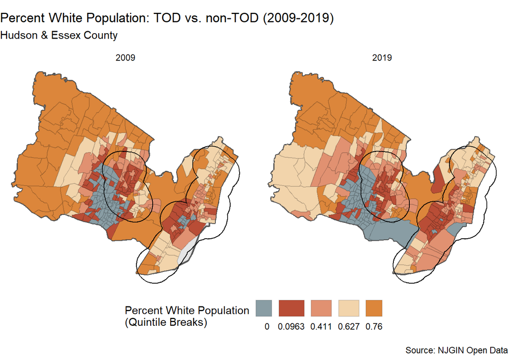

```r
ggplot() +
    geom_sf(data=st_union(allTracts.group), size=0.75) +
    geom_sf(data=(allTracts.group), aes(fill=q5(pctWhite)),color=colb) +
    geom_sf(data =buffer, color ="black", fill= NA, size=0.5)+
  scale_fill_manual(values = col5,
                    labels = qBr(allTracts.group, "pctWhite",rnd = F),
                    name = "Percent White Population\n(Quintile Breaks)") +
    labs(title="Percent White Population: TOD vs. non-TOD (2009-2019)",
       subtitle = "Hudson & Essex County\n",
       caption="\nSource: NJGIN Open Data") +
    facet_wrap(~year)+
    theme_void()+
  theme(legend.position="bottom")+
  guides(fill = guide_legend(label.position = "bottom", nrow = 1))
```

From the maps, there seems to be little change in the white population within the TOD region and a slight decrease in the non-TOD regions. From the following graph (percentage of black population), it is evident that there is a lower proportion of black population as we move away from the light rail stations. This map, when overlaid with the indicators of rent, income and poverty, could imply that the ‘suburbs’ are occupied by wealthier residents. However, we do have to take into consideration the various public transit routes that connect these counties that are not shown in this map.

#### vi. Race: Percentage of Black Population (2009-2019)

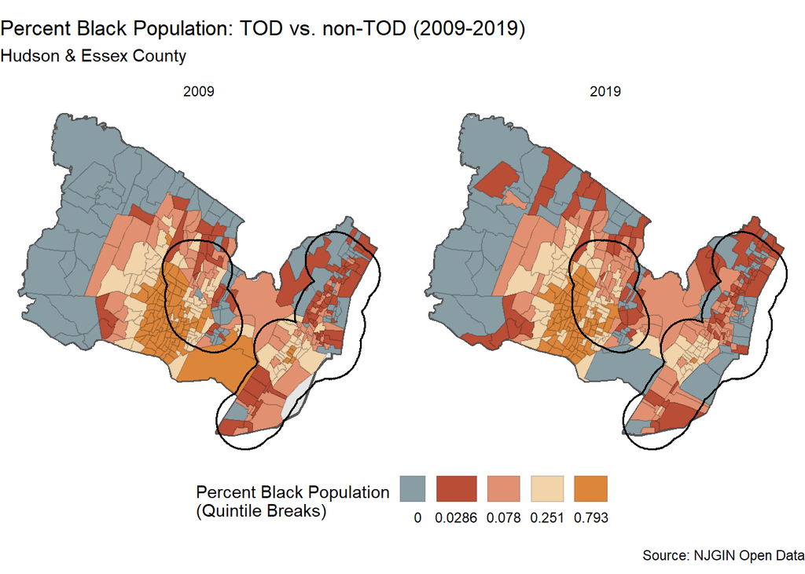

```r
ggplot() +
    geom_sf(data=st_union(allTracts.group), size=0.75) +
    geom_sf(data=(allTracts.group), aes(fill=q5(pctBlack)),color=colb) +
    geom_sf(data =buffer, color ="black", fill= NA, size=0.7)+
  scale_fill_manual(values = col5,
                    labels = qBr(allTracts.group, "pctBlack",rnd = F),
                    name = "Percent Black Population\n(Quintile Breaks)") +
    labs(title="Percent Black Population: TOD vs. non-TOD (2009-2019)",
       subtitle = "Hudson & Essex County\n",
       caption="\nSource: NJGIN Open Data") +
    facet_wrap(~year)+
    theme_void()+
  theme(legend.position="bottom")+
  guides(fill = guide_legend(label.position = "bottom", nrow = 1))
```

#### vii. Percentage of Bachelors (2009-2019)

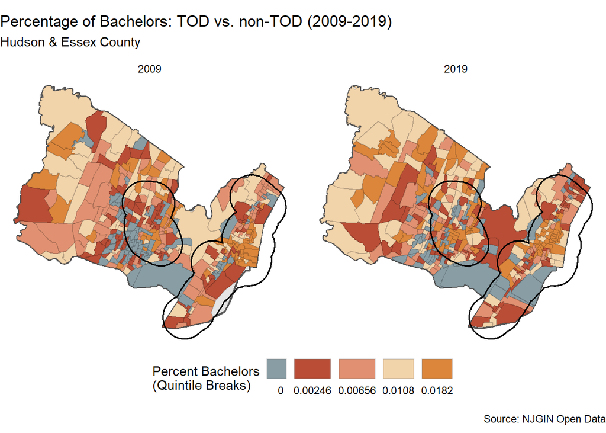

```r
ggplot() +
    geom_sf(data=st_union(allTracts.group), size=0.75) +
    geom_sf(data=(allTracts.group), aes(fill=q5(pctBachelors)),color=colb) +
    geom_sf(data =buffer, color ="black", fill= NA, size=0.7)+
  scale_fill_manual(values = col5,
                    labels = qBr(allTracts.group, "pctBachelors",rnd = F),
                    name = "Percent Bachelors\n(Quintile Breaks)") +
    labs(title="Percentage of Bachelors: TOD vs. non-TOD (2009-2019)",
       subtitle = "Hudson & Essex County\n",
       caption="\nSource: NJGIN Open Data") +
    facet_wrap(~year)+
    theme_void()+
  theme(legend.position="bottom")+
  guides(fill = guide_legend(label.position = "bottom", nrow = 1))
```

From the maps, there seems to be an increase in the number of people with a bachelors degree living in TOD zones. This could mean that this demographic is willing to pay the price to live closer to transit infrastructure. It could also imply an increase in purchasing power, which couldve been cemented with employment, education and age data.

# E. TOD Indicators Tables

```r
allTracts.Summary <-
  st_drop_geometry(allTracts.group) %>%
  group_by(year, TOD) %>%
  summarize(Rent = mean(MedRent, na.rm = T),
            Population = mean(TotalPop, na.rm = T),
            Percent_White = mean(pctWhite, na.rm = T),
            Percent_Black = mean(pctBlack, na.rm = T),
            Percent_Bach = mean(pctBachelors, na.rm = T),
            Percent_Poverty = mean(pctPoverty, na.rm = T),
            Med_HH_Income = mean(MedHHInc, na.rm = T),)

allTracts.Summary %>%
  unite(year.TOD, year, TOD, sep = ": ", remove = T) %>%
  gather(Variable, Value, -year.TOD) %>%
  mutate(Value = round(Value, 2)) %>%
  spread(year.TOD, Value) %>%
  kable() %>%
  kable_styling(html_font = "Cambria")
```

| Variable | 2009: Non-TOD | 2009: TOD | 2019: Non-TOD | 2019: TOD |
| --- | --- | --- | --- | --- |
| Med_HH_Income | 75763.60 | 49993.29 | 91977.99 | 64352.25 |
| Percent_Bach | 0.01 | 0.01 | 0.01 | 0.01 |
| Percent_Black | 0.59 | 0.29 | 0.43 | 0.24 |
| Percent_Poverty | 0.12 | 0.20 | 0.13 | 0.19 |
| Percent_White | 0.54 | 0.48 | 0.45 | 0.48 |
| Population | 3911.27 | 3430.43 | 3975.85 | 3728.10 |
| Rent | 1050.80 | 883.94 | 1392.53 | 1238.94 |

# F. TOD Indicators Plots

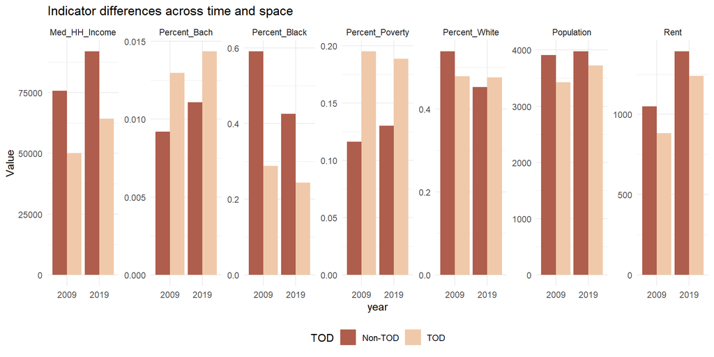

```r
allTracts.Summary %>%
  gather(Variable, Value, -year, -TOD) %>%
  ggplot(aes(year, Value, fill = TOD)) +
  geom_bar(stat = "identity", position = "dodge") +
  facet_wrap(~Variable, scales = "free", ncol=7) +
  scale_fill_manual(values = c("#af5d4c", "#f0c9aa")) +
  labs(title = "Indicator differences across time and space") +
  theme_minimal() +
  theme(legend.position="bottom")
```

Differences in TOD indicators over time cam be clearly visualized through these plots and were used to make assumptions about income, rent, poverty and population that were referenced in the policy brief.

# G. Graduated Symbol Maps

### i. Graduated Symbol Map for Population

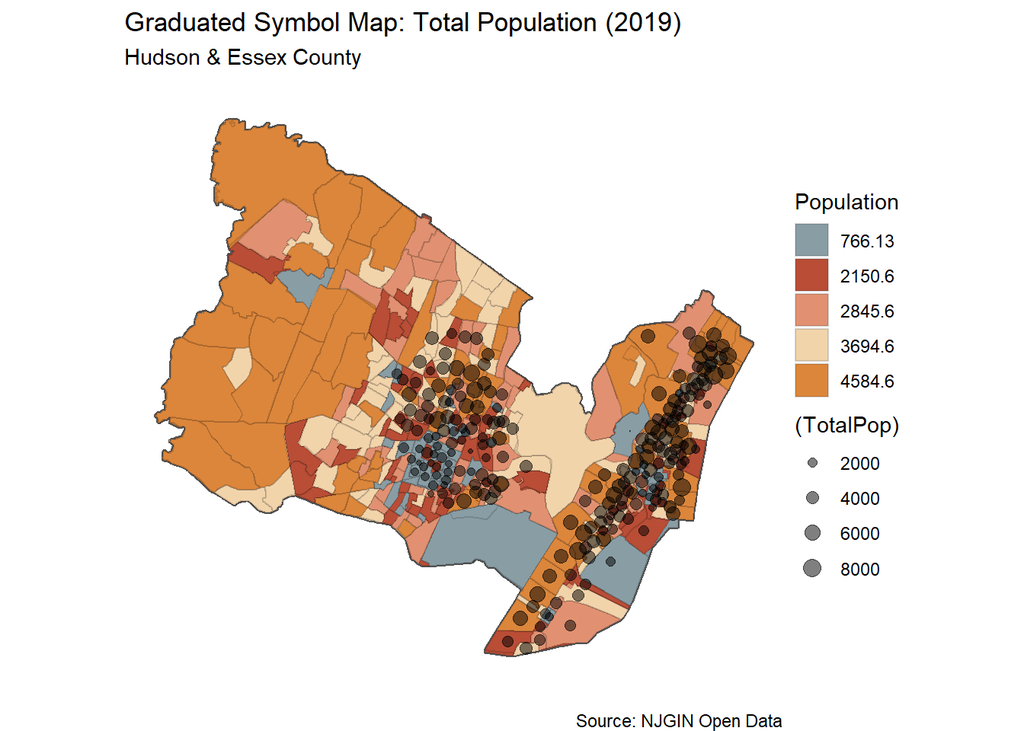

```r
center <- st_centroid(centroids)

ggplot() +
  geom_sf(data=st_union(allTracts.group), size=0.75) +
  geom_sf(data=allTracts.group, aes(fill = q5(TotalPop)), color = colb) +
  geom_sf(data=center, aes(size = (TotalPop)), pch = 21,
          fill = "black", alpha = 0.5) +
  scale_size_continuous(range = c(0.005,4)) +
  scale_fill_manual(values = col5,
    labels = qBr(center, "TotalPop"),
                    name = "Population") +
  labs(title="Graduated Symbol Map: Total Population (2019)",
       subtitle = "Hudson & Essex County\n",
       caption="\nSource: NJGIN Open Data") +
    theme_void()
```

### ii. Graduated Symbol Map for Rent

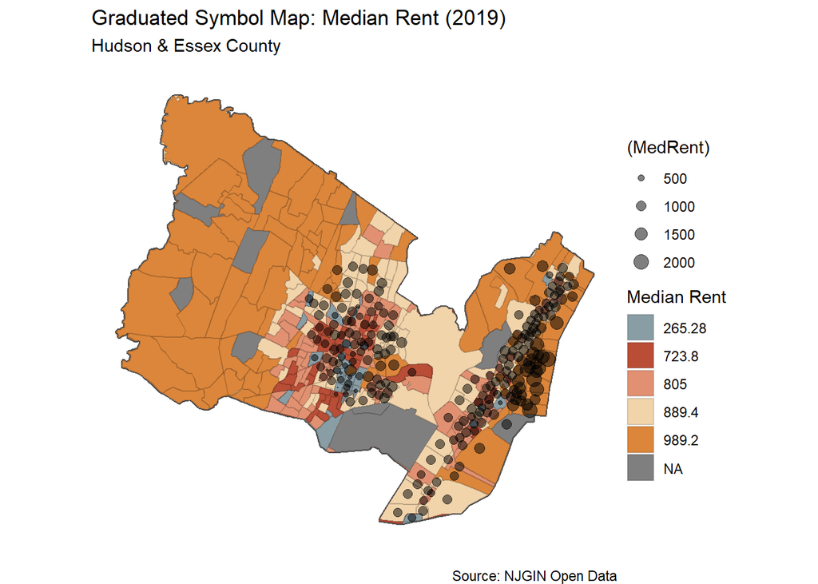

```r
center2 <- st_centroid(centroids2)

ggplot() +
  geom_sf(data=st_union(allTracts.group), size=0.75) +
  geom_sf(data=allTracts.group, aes(fill = q5(MedRent)), color = colb) +
  geom_sf(data=center2, aes(size = (MedRent)), pch = 21,
          fill = "black", alpha = 0.5) +
  scale_size_continuous(range = c(0.005,4)) +
  scale_fill_manual(values = col5,
    labels = qBr(center2, "MedRent"),
                    name = "Median Rent") +
  labs(title="Graduated Symbol Map: Median Rent (2019)",
       subtitle = "Hudson & Essex County\n",
       caption="\nSource: NJGIN Open Data") +
    theme_void()
```

# H. Multiple Ring Buffers

### I. Plotting Multiple Ring Buffers

```r
sf::sf_use_s2(FALSE)

NJ_Coords <- ("+proj=tmerc +lat_0=38.83333333333334 +lon_0=-74.5 +k=0.9999 +x_0=150000 +y_0=0 +ellps=GRS80 +datum=NAD83 +to_meter=0.3048006096012192 +no_defs ")

NJ_Stops_2 <- st_read("C:/Users/Chris Michael/Desktop/UPenn/Fall 2022/508/MUSA_508_Lab-main/MUSA_508_Lab-main/Week_2/Light_Rail_Stations_of_NJ_Transit.geojson")%>%st_transform(st_crs(NJ_Coords))%>%
  filter(COUNTY %in% c ("Hudson","Essex"))


NJ_Buffer_2 <- multipleRingBuffer(st_union(NJ_Stops_2),
                                maxDistance = 63360,
                                interval =  2640) %>%
  st_transform(st_crs(NJ_Coords))
```

The multiple ring buffers were created at 1/2 mile intervals and were used to plot the graph of rent as a function of distance- to visualize the changes in median rent as we move further away from TOD zones.

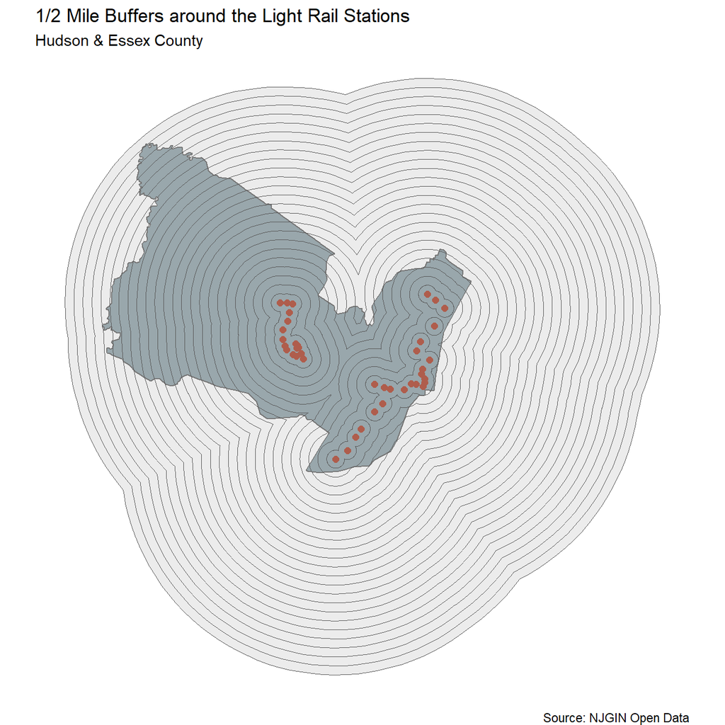

```r
ggplot() +
  geom_sf(data=st_union(tracts19), fill="#899da4") +
    geom_sf(data=NJ_Buffer_2,fill="grey", size=0.2, alpha=0.3) +
    geom_sf(data=NJ_Stops_2, color="#af5d4c",size=2) +
    labs(title="1/2 Mile Buffers around the Light Rail Stations",
       subtitle="Hudson & Essex County",
       caption="Source: NJGIN Open Data") +
  theme_void()+
  theme(legend.position="bottom")
```

### II. Plotting Rent vs. Distance to the Light Rail

```r
sf::sf_use_s2(FALSE)

NJ_Buffer_2 <- multipleRingBuffer(st_union(NJ_Stops_2),
                                maxDistance = 63360,
                                interval =  2640) %>%
  st_transform(st_crs(tracts19))


MRB_1 <- st_join(NJ_Buffer_2, tracts19, by = "geometry")%>%
  dplyr::mutate(MedRent_19 = MedRent)%>%
  select(c('distance','GEOID','MedRent_19','geometry'))%>%
  st_set_geometry(NULL) %>%
  replace(is.na(.), 0)

MRB_A = MRB_1 %>% group_by(distance)  %>%
                    summarise(MedRent_19 = mean(MedRent_19))


MRB_2 <- st_join(NJ_Buffer_2, tracts09, by = "geometry")%>%
  dplyr::mutate(MedRent_09 = MedRent*1.19)%>%
  select(c('distance','GEOID','MedRent_09','geometry'))%>%
  st_set_geometry(NULL) %>%
  replace(is.na(.), 0)

MRB_B = MRB_2 %>% group_by(distance)  %>%
                    summarise(MedRent_09 = mean(MedRent_09))

MRB <- full_join(MRB_A, MRB_B, by = "distance") %>%
  drop_na()
```

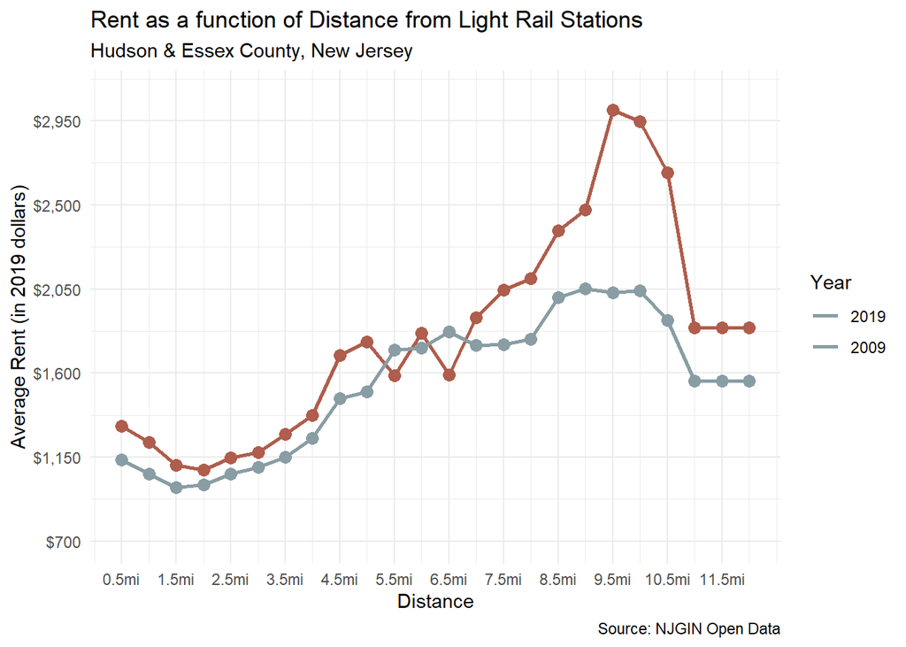

```r
ggplot(data = MRB, aes(x = distance)) +
  geom_line(aes(y = MedRent_19), color = "#af5d4c", size = 1, show.legend = TRUE)+
  geom_point(aes(y = MedRent_19), color = "#af5d4c", size = 3)+
  geom_line(aes(y = MedRent_09), color="#899da4", size = 1, show.legend = TRUE)+
  geom_point(aes(y = MedRent_09), color = "#899da4", size = 3)+
  scale_x_continuous(name = "Distance",
                     limits = c(2640, 63360),
                     breaks = seq(2640, 63360, by=5280),
                     labels = c("0.5mi","1.5mi","2.5mi","3.5mi","4.5mi","5.5mi",
                                "6.5mi","7.5mi","8.5mi","9.5mi","10.5mi","11.5mi"))+
  scale_y_continuous(name = "Average Rent (in 2019 dollars)",
                     limits = c(700,3100),
                     breaks = seq(700,3100, by=450),
                     labels = c ("$700","$1,150","$1,600","$2,050","$2,500","$2,950"))+
  labs(title = "Rent as a function of Distance from Light Rail Stations",
       subtitle="Hudson & Essex County, New Jersey",
       caption="Source: NJGIN Open Data") +
   scale_color_manual(name='Year',
                     breaks=c('2019', '2009'),
                     values=c('2019'='#af5d4c', '2009'='#899da4'))+
  theme_minimal()
```

The rent values have been adjusted for inflation. The analysis of the graph will exclude the two outliers in the 2019 data. From the graph, the median rent seems to decrease as we move away from the TOD zones, but begins to climb again after a certain distance (2.5 miles). The rent seems to continue to climb as the distance increase, which could imply a hike in housing prices as we move into the ‘suburbs’. The rent values start to drop again after 9.5 miles and then becomes constant after 11 miles from the TOD zones. These areas could be seeing fewer newer developments compared to regions closer to public transit, and do not offer as many incentives for residents to move to the area.